# Space-Time Prediction of Bike Share Demand for NYC

Yuhao Jia

November 17, 2022

# 1. Introduction

Bike share system need to ‘re-balance’ bicycles across the network.Figuring out how to do this is one of the keys to operating a successful system.

Success to predict bike share demand for each station is essential for move bikes to the right place with trucks for the bike share company. This is also the aim of this project.

In this project, we will use time-space predictive modeling to predict the bike share pattern of each hour in New York City and try to address an operations issue for the citi-bike system provided by lyft.

# 2. Loading data

## 2.1. Setup

First load some libraries.

```r
library(tidyverse)
library(sf)
library(lubridate)
library(tigris)
library(tidycensus)
library(viridis)
library(riem)
library(gridExtra)
library(knitr)
library(kableExtra)
library(RSocrata)
library(caret)
library(gganimate)
library(gifski)

plotTheme <- theme(
  plot.title =element_text(size=12),
  plot.subtitle = element_text(size=8),
  plot.caption = element_text(size = 6),
  axis.text.x = element_text(size = 10, angle = 45, hjust = 1),
  axis.text.y = element_text(size = 10),
  axis.title.y = element_text(size = 10),
  # Set the entire chart region to blank
  panel.background=element_blank(),
  plot.background=element_blank(),
  #panel.border=element_rect(colour="#F0F0F0"),
  # Format the grid
  panel.grid.major=element_line(colour="#D0D0D0",size=.2),
  axis.ticks=element_blank())

mapTheme <- theme(plot.title =element_text(size=12),
                  plot.subtitle = element_text(size=8),
                  plot.caption = element_text(size = 6),
                  axis.line=element_blank(),
                  axis.text.x=element_blank(),
                  axis.text.y=element_blank(),
                  axis.ticks=element_blank(),
                  axis.title.x=element_blank(),
                  axis.title.y=element_blank(),
                  panel.background=element_blank(),
                  panel.border=element_blank(),
                  panel.grid.major=element_line(colour = 'transparent'),
                  panel.grid.minor=element_blank(),
                  legend.direction = "vertical",
                  legend.position = "right",
                  plot.margin = margin(1, 1, 1, 1, 'cm'),
                  legend.key.height = unit(1, "cm"), legend.key.width = unit(0.2, "cm"))

palette5 <- c("#eff3ff","#bdd7e7","#6baed6","#3182bd","#08519c")
palette4 <- c("#D2FBD4","#92BCAB","#527D82","#123F5A")
palette2 <- c("#6baed6","#08519c")
```

Load your census API key so we can grab stuff from `tidycensus`

```r
# Install Census API Key
# census_api_key("YOUR KEY GOES HERE", overwrite = TRUE)
```

## 2.2. Import Data

Dataset “citi bike trips New York City” from 2020-5-01 to 2020-5-31 are be used for training/testing model.

```r
dat <- read.csv("D:/UPenn/Fall2022/5080Policy/HW_data/bikeshare/JC-202005-citibike-tripdata.csv")
```

Take a look at the data to have a basic understanding of all information. It is noticed that most of the bike stations’ address is in the Jersey city and Manhattan area, which means those trips in this data set mainly happened in this area.

Date parsing tool was used to bin” the data by 15 and 60 minute intervals by rounding.

```r
dat2 <- dat %>%
  mutate(interval60 = floor_date(mdy_hm(starttime), unit = "hour"),
         interval15 = floor_date(mdy_hm(starttime), unit = "15 mins"),
         week = week(interval60),
         dotw = wday(interval60, label=TRUE))

glimpse(dat2)
```

```
## Rows: 25,077
## Columns: 19
## $ tripduration            <int> 349, 138, 229, 261, 168, 500, 237, 144, 2295, …
## $ starttime               <chr> "5/1/2020 0:09", "5/1/2020 1:11", "5/1/2020 5:…
## $ stoptime                <chr> "5/1/2020 0:15", "5/1/2020 1:13", "5/1/2020 5:…
## $ start.station.id        <int> 3195, 3792, 3483, 3278, 3194, 3209, 3678, 3279…
## $ start.station.name      <chr> "Sip Ave", "Columbus Dr at Exchange Pl", "Mont…
## $ start.station.latitude  <dbl> 40.73090, 40.71687, 40.71942, 40.72569, 40.725…
## $ start.station.longitude <dbl> -74.06391, -74.03281, -74.05099, -74.04879, -7…
## $ end.station.id          <int> 3280, 3639, 3186, 3186, 3195, 3225, 3195, 3186…
## $ end.station.name        <chr> "Astor Place", "Harborside", "Grove St PATH", …
## $ end.station.latitude    <dbl> 40.71928, 40.71925, 40.71959, 40.71959, 40.730…
## $ end.station.longitude   <dbl> -74.07126, -74.03423, -74.04312, -74.04312, -7…
## $ bikeid                  <int> 42581, 42105, 42320, 42170, 42352, 42208, 4250…
## $ usertype                <chr> "Customer", "Subscriber", "Customer", "Subscri…
## $ birth.year              <int> 1969, 1949, 1984, 1974, 1966, 1982, 1981, 1970…
## $ gender                  <int> 0, 1, 1, 2, 1, 1, 1, 1, 1, 1, 1, 2, 2, 2, 1, 1…
## $ interval60              <dttm> 2020-05-01 00:00:00, 2020-05-01 01:00:00, 202…
## $ interval15              <dttm> 2020-05-01 00:00:00, 2020-05-01 01:00:00, 202…
## $ week                    <dbl> 18, 18, 18, 18, 18, 18, 18, 18, 18, 18, 18, 18…
## $ dotw                    <ord> Fri, Fri, Fri, Fri, Fri, Fri, Fri, Fri, Fri, F…
```

## 2.3. Import Census Info

As most trips in this data set mainly happened in Jersey City and Manhattan area, census data of this two areas are loaded and bind as “NYCTracts”. And then the bike share data and “NYCTracts” are joined together as “dat_census”.

```r
NYCCensus <-
  get_acs(geography = "tract",
          variables = c("B01003_001", "B19013_001",
                        "B02001_002", "B08013_001",
                        "B08012_001", "B08301_001",
                        "B08301_010", "B01002_001"),
          year = 2020,
          state = "NY",
          geometry = TRUE,
          county=c("New York"),
          output = "wide") %>%
  rename(Total_Pop =  B01003_001E,
         Med_Inc = B19013_001E,
         Med_Age = B01002_001E,
         White_Pop = B02001_002E,
         Travel_Time = B08013_001E,
         Num_Commuters = B08012_001E,
         Means_of_Transport = B08301_001E,
         Total_Public_Trans = B08301_010E) %>%
  select(Total_Pop, Med_Inc, White_Pop, Travel_Time,
         Means_of_Transport, Total_Public_Trans,
         Med_Age,
         GEOID, geometry) %>%
  mutate(Percent_White = White_Pop / Total_Pop,
         Mean_Commute_Time = Travel_Time / Total_Public_Trans,
         Percent_Taking_Public_Trans = Total_Public_Trans / Means_of_Transport)

NJCensus <-
  get_acs(geography = "tract",
          variables = c("B01003_001", "B19013_001",
                        "B02001_002", "B08013_001",
                        "B08012_001", "B08301_001",
                        "B08301_010", "B01002_001"),
          year = 2020,
          state = "NJ",
          geometry = TRUE,
          county=c("Hudson"),
          output = "wide") %>%
  rename(Total_Pop =  B01003_001E,
         Med_Inc = B19013_001E,
         Med_Age = B01002_001E,
         White_Pop = B02001_002E,
         Travel_Time = B08013_001E,
         Num_Commuters = B08012_001E,
         Means_of_Transport = B08301_001E,
         Total_Public_Trans = B08301_010E) %>%
  select(Total_Pop, Med_Inc, White_Pop, Travel_Time,
         Means_of_Transport, Total_Public_Trans,
         Med_Age,
         GEOID, geometry) %>%
  mutate(Percent_White = White_Pop / Total_Pop,
         Mean_Commute_Time = Travel_Time / Total_Public_Trans,
         Percent_Taking_Public_Trans = Total_Public_Trans / Means_of_Transport)

Census <- rbind(NYCCensus,NJCensus)
```

```r
NYCTracts <-
  Census %>%
  as.data.frame() %>%
  distinct(GEOID, .keep_all = TRUE) %>%
  select(GEOID, geometry) %>%
  st_sf
```

```r
dat_census <- st_join(dat2 %>%
          filter(is.na(start.station.longitude) == FALSE &
                   is.na(start.station.latitude) == FALSE &
                   is.na(end.station.latitude) == FALSE &
                   is.na(end.station.longitude) == FALSE) %>%
          st_as_sf(., coords = c("start.station.longitude", "start.station.latitude"), crs = 4326),
        NYCTracts %>%
          st_transform(crs=4326),
        join=st_intersects,
              left = TRUE) %>%
  rename(Origin.Tract = GEOID) %>%
  mutate(from_longitude = unlist(map(geometry, 1)),
         from_latitude = unlist(map(geometry, 2)))%>%
  as.data.frame() %>%
  select(-geometry)%>%
  st_as_sf(., coords = c("end.station.longitude", "end.station.latitude"), crs = 4326) %>%
  st_join(., NYCTracts %>%
            st_transform(crs=4326),
          join=st_intersects,
          left = TRUE) %>%
  rename(Destination.Tract = GEOID)  %>%
  mutate(to_longitude = unlist(map(geometry, 1)),
         to_latitude = unlist(map(geometry, 2)))%>%
  as.data.frame() %>%
  select(-geometry)
```

## 2.4. Import Weather Data

Import weather data from station New York City (code NYC) using `riem_measures`. Temperature, preceipitation and wind speed data was downloaded for the study period.

```r
weather.Panel <-
  riem_measures(station = "NYC", date_start = "2020-05-01", date_end = "2020-05-31") %>%
  dplyr::select(valid, tmpf, p01i, sknt)%>%
  replace(is.na(.), 0) %>%
    mutate(interval60 = ymd_h(substr(valid,1,13))) %>%
    mutate(week = week(interval60),
           dotw = wday(interval60, label=TRUE)) %>%
    group_by(interval60) %>%
    summarize(Temperature = max(tmpf),
              Precipitation = sum(p01i),
              Wind_Speed = max(sknt)) %>%
    mutate(Temperature = ifelse(Temperature == 0, 42, Temperature))

glimpse(weather.Panel)
```

```
## Rows: 720
## Columns: 4
## $ interval60    <dttm> 2020-05-01 00:00:00, 2020-05-01 01:00:00, 2020-05-01 02…
## $ Temperature   <dbl> 57.9, 57.9, 55.0, 55.0, 55.0, 54.0, 55.0, 55.0, 54.0, 54…
## $ Precipitation <dbl> 0.1301, 0.1800, 0.0600, 0.0200, 0.0200, 0.0800, 0.0400, …
## $ Wind_Speed    <dbl> 13, 10, 11, 10, 0, 8, 3, 0, 0, 0, 0, 3, 6, 5, 5, 5, 0, 3…
```

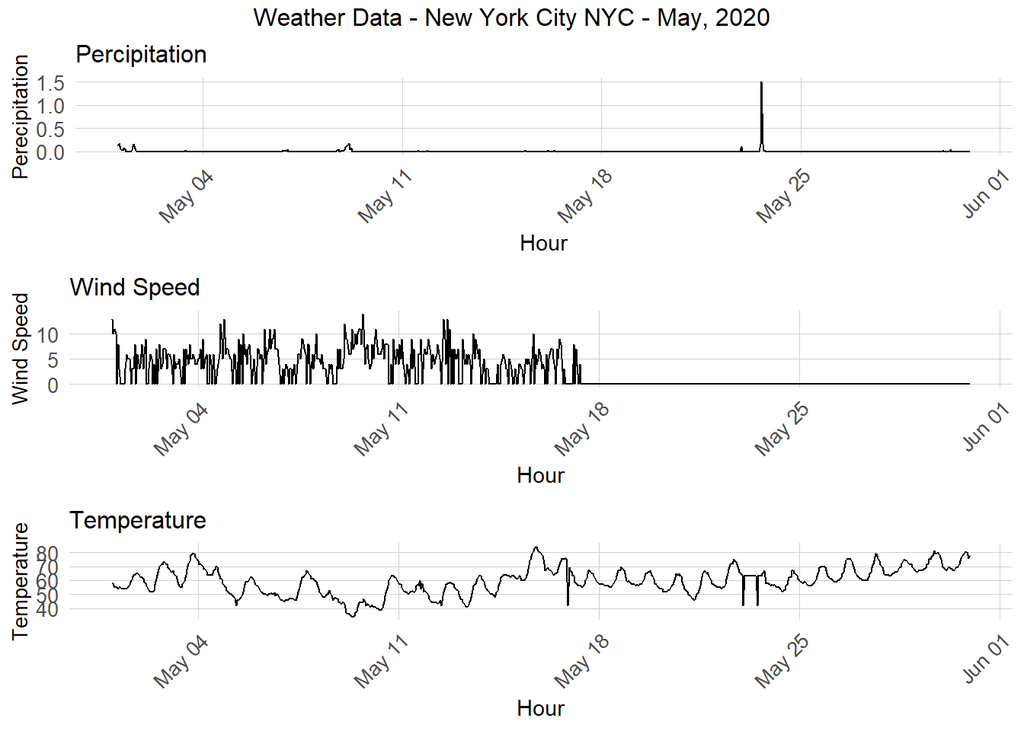

```r
grid.arrange(
  ggplot(weather.Panel, aes(interval60,Precipitation)) + geom_line() +
  labs(title="Percipitation", x="Hour", y="Perecipitation") + plotTheme,
  ggplot(weather.Panel, aes(interval60,Wind_Speed)) + geom_line() +
    labs(title="Wind Speed", x="Hour", y="Wind Speed") + plotTheme,
  ggplot(weather.Panel, aes(interval60,Temperature)) + geom_line() +
    labs(title="Temperature", x="Hour", y="Temperature") + plotTheme,
  top="Weather Data - New York City NYC - May, 2020")
```

# 3. Data Exploratory & Feature Engineering

## 3.1. Describe and Explore the Data

First, time and frequency components of our data were examined.

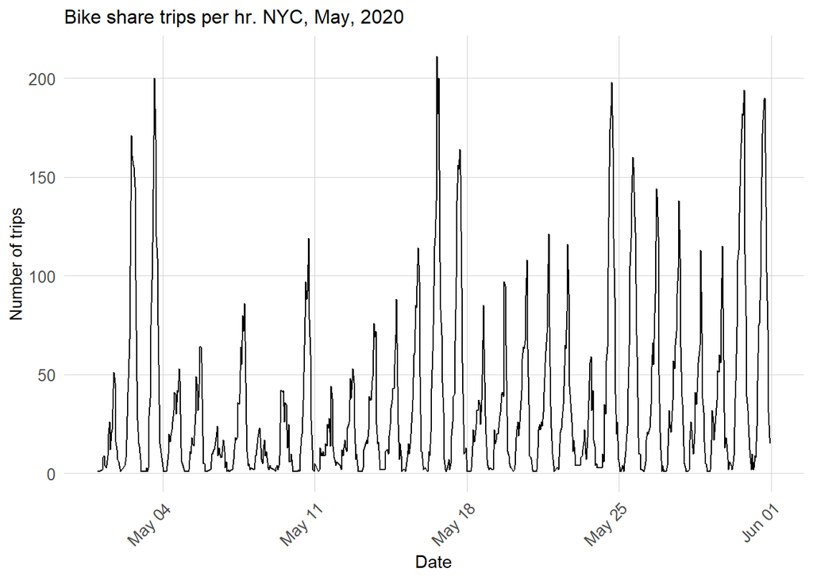

```r
ggplot(dat_census %>%
         group_by(interval60) %>%
         tally())+
  geom_line(aes(x = interval60, y = n))+
  labs(title="Bike share trips per hr. NYC, May, 2020",
       x="Date",
       y="Number of trips")+
  plotTheme
```

The distribution of trip volume by station for different times of the day was examined. It is noticed that the data must consist of a lot of low demand station/hours and a few high demand station hours. The Mid-Day and PM rush period have clearly higher demand than AM Rush and Overnight period, which is reasonable.

The daily trends in ridership by day of the week and weekend versus weekday were tracked, there are clearly temporal patterns and difference between weekday and weekend, which need to be controlled for.

The bike share trips by station and period was also examined and visualized as an animated gif. It shows spatial cluster of demand during mid day and pm rush period.

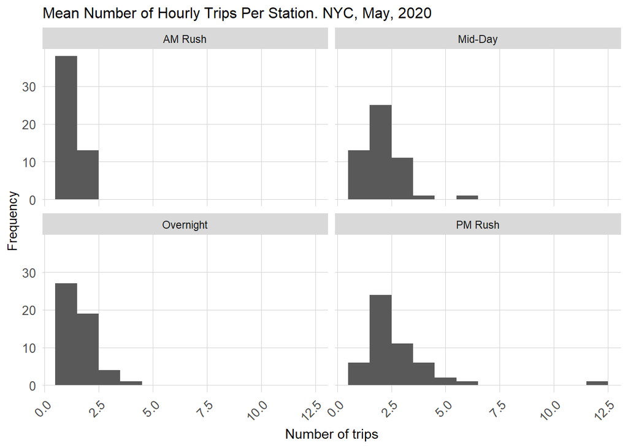

```r
dat_census %>%
        mutate(time_of_day = case_when(hour(interval60) < 7 | hour(interval60) > 18 ~ "Overnight",
                                 hour(interval60) >= 7 & hour(interval60) < 10 ~ "AM Rush",
                                 hour(interval60) >= 10 & hour(interval60) < 15 ~ "Mid-Day",
                                 hour(interval60) >= 15 & hour(interval60) <= 18 ~ "PM Rush"))%>%
         group_by(interval60, start.station.name, time_of_day) %>%
         tally()%>%
  group_by(start.station.name, time_of_day)%>%
  summarize(mean_trips = mean(n))%>%
  ggplot()+
  geom_histogram(aes(mean_trips), binwidth = 1)+
  labs(title="Mean Number of Hourly Trips Per Station. NYC, May, 2020",
       x="Number of trips",
       y="Frequency")+
  facet_wrap(~time_of_day)+
  plotTheme
```

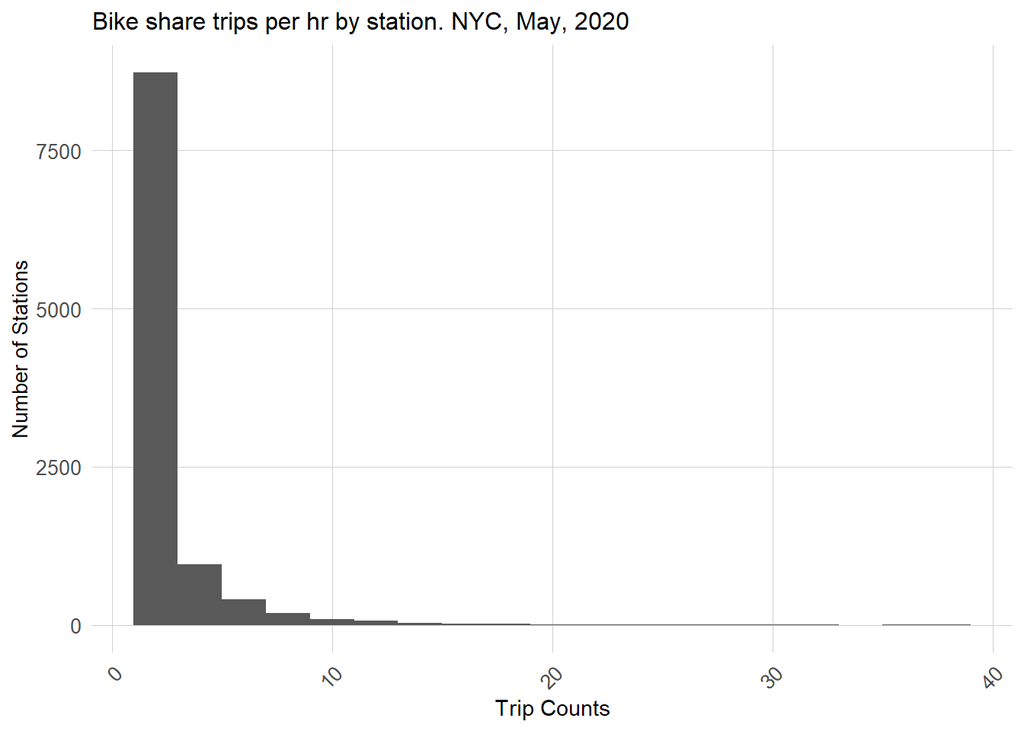

```r
ggplot(dat_census %>%
         group_by(interval60, start.station.name) %>%
         tally())+
  geom_histogram(aes(n), binwidth = 2)+
  labs(title="Bike share trips per hr by station. NYC, May, 2020",
       x="Trip Counts",
       y="Number of Stations")+
  plotTheme
```

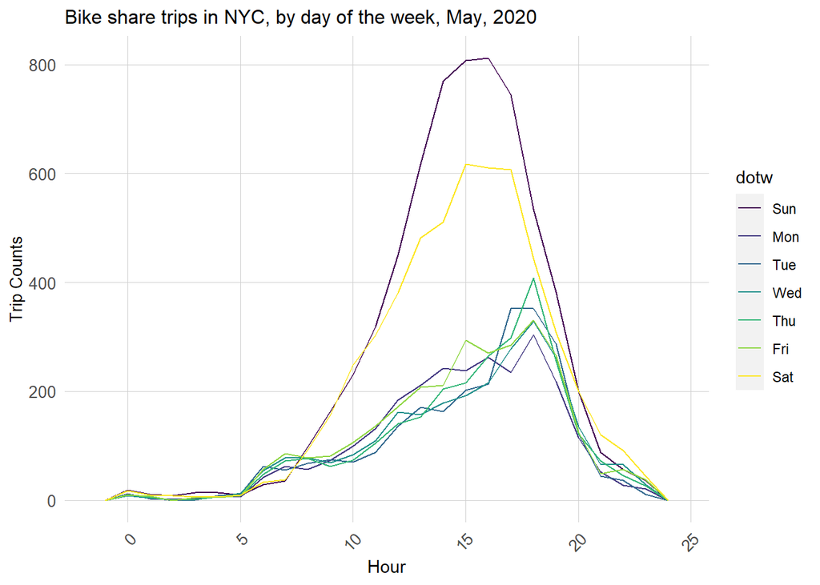

```r
ggplot(dat_census %>% mutate(hour = hour(interval60)))+
     geom_freqpoly(aes(hour, color = dotw), binwidth = 1)+
  labs(title="Bike share trips in NYC, by day of the week, May, 2020",
       x="Hour",
       y="Trip Counts")+
     plotTheme
```

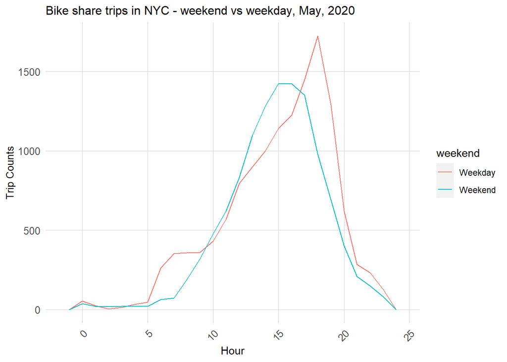

```r
ggplot(dat_census %>%
         mutate(hour = hour(interval60),
                weekend = ifelse(dotw %in% c("Sun", "Sat"), "Weekend", "Weekday")))+
     geom_freqpoly(aes(hour, color = weekend), binwidth = 1)+
  labs(title="Bike share trips in NYC - weekend vs weekday, May, 2020",
       x="Hour",
       y="Trip Counts")+
     plotTheme
```

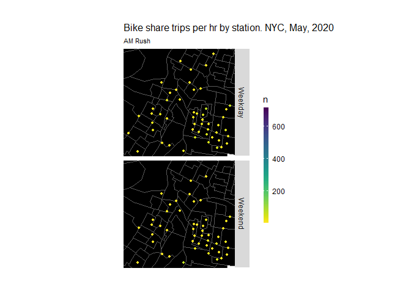

```r
dat_census$starttime <- as.numeric(dat_census$starttime)
rideshare_animation <-
ggplot()+
  geom_sf(data = NYCTracts %>%
          st_transform(crs=4326),fill = "black")+
  geom_point(data = dat_census %>%
            mutate(hour = hour(starttime),
                weekend = ifelse(dotw %in% c("Sun", "Sat"), "Weekend", "Weekday"),
                time_of_day = case_when(hour(interval60) < 7 | hour(interval60) > 18 ~ "Overnight",
                                 hour(interval60) >= 7 & hour(interval60) < 10 ~ "AM Rush",
                                 hour(interval60) >= 10 & hour(interval60) < 15 ~ "Mid-Day",
                                 hour(interval60) >= 15 & hour(interval60) <= 18 ~ "PM Rush"))%>%
              group_by(start.station.id, from_latitude, from_longitude, weekend, time_of_day) %>%
              tally(),
            aes(x=from_longitude, y = from_latitude, color = n),
            fill = "transparent", alpha = 1, size = 1)+
  scale_colour_viridis(direction = -1,
  discrete = FALSE, option = "D")+
  ylim(min(dat_census$from_latitude), max(dat_census$from_latitude))+
  xlim(min(dat_census$from_longitude), max(dat_census$from_longitude))+
  facet_grid(weekend ~ .)+
  labs(title="Bike share trips per hr by station. NYC, May, 2020",
       subtitle = "{current_frame}")+
  transition_manual(time_of_day)+
  mapTheme

animate(rideshare_animation, duration=10, renderer = gifski_renderer())
```

## 3.2 Create Space-Time Panel

In this section, a space-time panel for modeling will be created. First a study panel with 34782 rows was created to make sure each unique station and hour/day combo exists in our data set.

```r
study.panel <-
  expand.grid(interval60=unique(dat_census$interval60),
              start.station.id = unique(dat_census$start.station.id)) %>%
  left_join(., dat_census %>%
              select(start.station.id, start.station.name, Origin.Tract, from_longitude, from_latitude )%>%
              distinct() %>%
              group_by(start.station.id) %>%
              slice(1))

nrow(study.panel)
```

```
## [1] 34782
```

Then the full panel was created by summarizing counts by station for each time interval, keep census info and lat/lon information along for joining later to other data. Data was removed for station IDs that are `FALSE`.

```r
ride.panel <-
  dat_census %>%
  mutate(Trip_Counter = 1) %>%
  right_join(study.panel) %>%
  group_by(interval60, start.station.id, start.station.name, Origin.Tract, from_longitude, from_latitude) %>%
  summarize(Trip_Count = sum(Trip_Counter, na.rm=T)) %>%
  left_join(weather.Panel) %>%
  ungroup() %>%
  filter(is.na(start.station.id) == FALSE) %>%
  mutate(week = week(interval60),
         dotw = wday(interval60, label = TRUE)) %>%
  filter(is.na(Origin.Tract) == FALSE)
```

```r
ride.panel <-
  left_join(ride.panel, Census %>%
              as.data.frame() %>%
              select(-geometry), by = c("Origin.Tract" = "GEOID"))
```

## 3.3. Create time lags

Intuitive sense is that the demand right now should be relatively similar to the demand tomorrow at this time, and to the demand an hour from now, but twelve hours from now, we likely expect the opposite in terms of demand.

So lag variables were also created as fixed effects, and correlations in this lags were also calculated and proved strong.

```r
ride.panel <-
  ride.panel %>%
  arrange(start.station.id, interval60) %>%
  mutate(lagHour = dplyr::lag(Trip_Count,1),
         lag2Hours = dplyr::lag(Trip_Count,2),
         lag3Hours = dplyr::lag(Trip_Count,3),
         lag4Hours = dplyr::lag(Trip_Count,4),
         lag12Hours = dplyr::lag(Trip_Count,12),
         lag1day = dplyr::lag(Trip_Count,24),
         holiday = ifelse(yday(interval60) == 148,1,0)) %>%
   mutate(day = yday(interval60)) %>%
   mutate(holidayLag = case_when(dplyr::lag(holiday, 1) == 1 ~ "PlusOneDay",
                                 dplyr::lag(holiday, 2) == 1 ~ "PlustTwoDays",
                                 dplyr::lag(holiday, 3) == 1 ~ "PlustThreeDays",
                                 dplyr::lead(holiday, 1) == 1 ~ "MinusOneDay",
                                 dplyr::lead(holiday, 2) == 1 ~ "MinusTwoDays",
                                 dplyr::lead(holiday, 3) == 1 ~ "MinusThreeDays"),
         holidayLag = ifelse(is.na(holidayLag) == TRUE, 0, holidayLag))
```

```r
as.data.frame(ride.panel) %>%
    group_by(interval60) %>%
    summarise_at(vars(starts_with("lag"), "Trip_Count"), mean, na.rm = TRUE) %>%
    gather(Variable, Value, -interval60, -Trip_Count) %>%
    mutate(Variable = factor(Variable, levels=c("lagHour","lag2Hours","lag3Hours","lag4Hours",
                                                "lag12Hours","lag1day")))%>%
    group_by(Variable) %>%
    summarize(correlation = round(cor(Value, Trip_Count),2))
```

```
## # A tibble: 6 × 2
##   Variable   correlation
##   <fct>            <dbl>
## 1 lagHour           0.92
## 2 lag2Hours         0.78
## 3 lag3Hours         0.6
## 4 lag4Hours         0.41
## 5 lag12Hours       -0.42
## 6 lag1day           0.56
```

# 4. Prediction Models

## 4.1. Run Models

Using training data, five linear models were created to see how different variables effect the power of the model. The first models include only temporal controls, but the later ones contain all of our lag information.

```r
ride.Train <- filter(ride.panel, week >= 20)
ride.Test <- filter(ride.panel, week < 20)
```

```r
reg1 <-
  lm(Trip_Count ~  hour(interval60) + dotw + Temperature,  data=ride.Train)

reg2 <-
  lm(Trip_Count ~  start.station.name + dotw + Temperature,  data=ride.Train)

reg3 <-
  lm(Trip_Count ~  start.station.name + hour(interval60) + dotw + Temperature + Precipitation,
     data=ride.Train)

reg4 <-
  lm(Trip_Count ~  start.station.name +  hour(interval60) + dotw + Temperature + Precipitation +
                   lagHour + lag2Hours +lag3Hours + lag12Hours + lag1day,
     data=ride.Train)

reg5 <-
  lm(Trip_Count ~  start.station.name + hour(interval60) + dotw + Temperature + Precipitation +
                   lagHour + lag2Hours +lag3Hours +lag12Hours + lag1day + holidayLag + holiday,
     data=ride.Train)
```

## 4.2. Predict for test data

After finishing runing models, a nested data frame of test data by week was created.

```r
ride.Test.weekNest <-
  ride.Test %>%
  nest(-week)
```

```r
model_pred <- function(dat, fit){
   pred <- predict(fit, newdata = dat)}
```

```r
week_predictions <-
  ride.Test.weekNest %>%
    mutate(ATime_FE = map(.x = data, fit = reg1, .f = model_pred),
           BSpace_FE = map(.x = data, fit = reg2, .f = model_pred),
           CTime_Space_FE = map(.x = data, fit = reg3, .f = model_pred),
           DTime_Space_FE_timeLags = map(.x = data, fit = reg4, .f = model_pred),
           ETime_Space_FE_timeLags_holidayLags = map(.x = data, fit = reg5, .f = model_pred)) %>%
    gather(Regression, Prediction, -data, -week) %>%
    mutate(Observed = map(data, pull, Trip_Count),
           Absolute_Error = map2(Observed, Prediction,  ~ abs(.x - .y)),
           MAE = map_dbl(Absolute_Error, mean, na.rm = TRUE),
           sd_AE = map_dbl(Absolute_Error, sd, na.rm = TRUE))

week_predictions
```

```
## # A tibble: 10 × 8
##     week data                  Regression    Predi…¹ Obser…² Absol…³   MAE sd_AE
##    <dbl> <list>                <chr>         <list>  <list>  <list>  <dbl> <dbl>
##  1    18 <tibble [5,202 × 30]> ATime_FE      <dbl>   <dbl>   <dbl>   1.01  1.47
##  2    19 <tibble [7,548 × 30]> ATime_FE      <dbl>   <dbl>   <dbl>   0.615 0.860
##  3    18 <tibble [5,202 × 30]> BSpace_FE     <dbl>   <dbl>   <dbl>   1.01  1.37
##  4    19 <tibble [7,548 × 30]> BSpace_FE     <dbl>   <dbl>   <dbl>   0.728 0.846
##  5    18 <tibble [5,202 × 30]> CTime_Space_… <dbl>   <dbl>   <dbl>   0.996 1.35
##  6    19 <tibble [7,548 × 30]> CTime_Space_… <dbl>   <dbl>   <dbl>   0.702 0.834
##  7    18 <tibble [5,202 × 30]> DTime_Space_… <dbl>   <dbl>   <dbl>   0.812 1.15
##  8    19 <tibble [7,548 × 30]> DTime_Space_… <dbl>   <dbl>   <dbl>   0.534 0.751
##  9    18 <tibble [5,202 × 30]> ETime_Space_… <dbl>   <dbl>   <dbl>   0.814 1.15
## 10    19 <tibble [7,548 × 30]> ETime_Space_… <dbl>   <dbl>   <dbl>   0.533 0.750
## # … with abbreviated variable names ¹Prediction, ²Observed, ³Absolute_Error
```

Cross validation analysis was also run to test the power of the model over all. Here, the last model was used under a 100 folds cross validation. The overall accuracy (MAE around 0,7) also shows it’s a generally good model.

```r
fitControl <- trainControl(method = "cv", number = 100)
set.seed(825)

reg.cv <-
  train(Trip_Count ~  start.station.name + hour(interval60) + dotw + Temperature + Precipitation +
                   lagHour + lag2Hours +lag3Hours +lag12Hours + lag1day + holidayLag + holiday,
     data=ride.panel, method = "lm", trControl = fitControl, na.action = na.pass)

reg.cv
```

```
## Linear Regression
##
## 34782 samples
##    12 predictor
##
## No pre-processing
## Resampling: Cross-Validated (100 fold)
## Summary of sample sizes: 34435, 34434, 34435, 34435, 34434, 34434, ...
## Resampling results:
##
##   RMSE      Rsquared   MAE
##   1.320568  0.4061358  0.7310628
##
## Tuning parameter 'intercept' was held constant at a value of TRUE
```

# 5. Visualize Accuracy & Generalizability

To further explore the accuracy and generalizability, in this section, they were visualized.

## 5.1. Examine Error Metrics for Accuracy

The accuracy of 5 models was visualized in the following 2 plots.

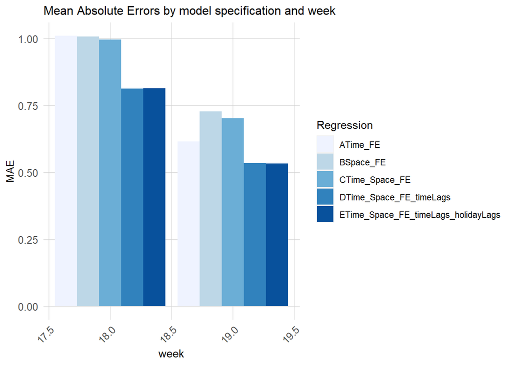

```r
week_predictions %>%
  dplyr::select(week, Regression, MAE) %>%
  gather(Variable, MAE, -Regression, -week) %>%
  ggplot(aes(week, MAE)) +
    geom_bar(aes(fill = Regression), position = "dodge", stat="identity") +
    scale_fill_manual(values = palette5) +
    labs(title = "Mean Absolute Errors by model specification and week") +
  plotTheme
```

[figure not shown]

```r
week_predictions %>%
    mutate(interval60 = map(data, pull, interval60),
           start.station.id = map(data, pull, start.station.id)) %>%
    dplyr::select(interval60, start.station.id, Observed, Prediction, Regression) %>%
    unnest() %>%
    gather(Variable, Value, -Regression, -interval60, -start.station.id) %>%
    group_by(Regression, Variable, interval60) %>%
    summarize(Value = sum(Value)) %>%
    ggplot(aes(interval60, Value, colour=Variable)) +
      geom_line(size = 1.1) +
      facet_wrap(~Regression, ncol=1) +
      labs(title = "Predicted/Observed bike share time series", subtitle = "Chicago; A test set of 2 weeks",  x = "Hour", y= "Station Trips") +
      plotTheme
```

By taking the MAE by station for the last model, there are still clusters at south-east area but not that strong.

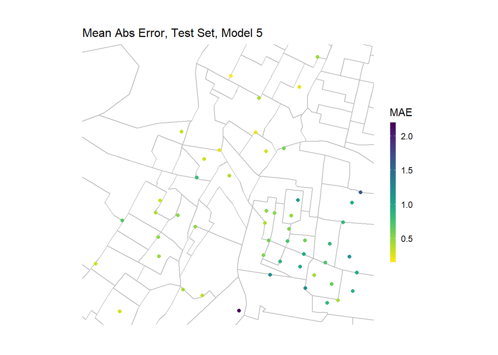

```r
week_predictions %>%
    mutate(interval60 = map(data, pull, interval60),
           start.station.id = map(data, pull, start.station.id),
           from_latitude = map(data, pull, from_latitude),
           from_longitude = map(data, pull, from_longitude)) %>%
    select(interval60, start.station.id, from_longitude, from_latitude, Observed, Prediction, Regression) %>%
    unnest() %>%
  filter(Regression == "ETime_Space_FE_timeLags_holidayLags") %>%
  group_by(start.station.id, from_longitude, from_latitude) %>%
  summarize(MAE = mean(abs(Observed-Prediction), na.rm = TRUE))%>%
ggplot(.)+
  geom_sf(data = Census, color = "grey", fill = "transparent")+
  geom_point(aes(x = from_longitude, y = from_latitude, color = MAE),
             fill = "transparent", alpha = 1)+
  scale_colour_viridis(direction = -1,
  discrete = FALSE, option = "D")+
  ylim(min(dat_census$from_latitude), max(dat_census$from_latitude))+
  xlim(min(dat_census$from_longitude), max(dat_census$from_longitude))+
  labs(title="Mean Abs Error, Test Set, Model 5")+
  mapTheme
```

## 5.2. Space-Time Error Evaluation

In this section, the generalizability of the last model was tested through weekdays/weekends, different period of a day, and socio-economic variables.

By plotting observed vs. predicted for different times of day during the week and weekend, it can be seen that the coefficients (red lines) are lower than 1 (black line). This indicates that the model is underpredicting in general but it’s more accurate at weekend overnight.

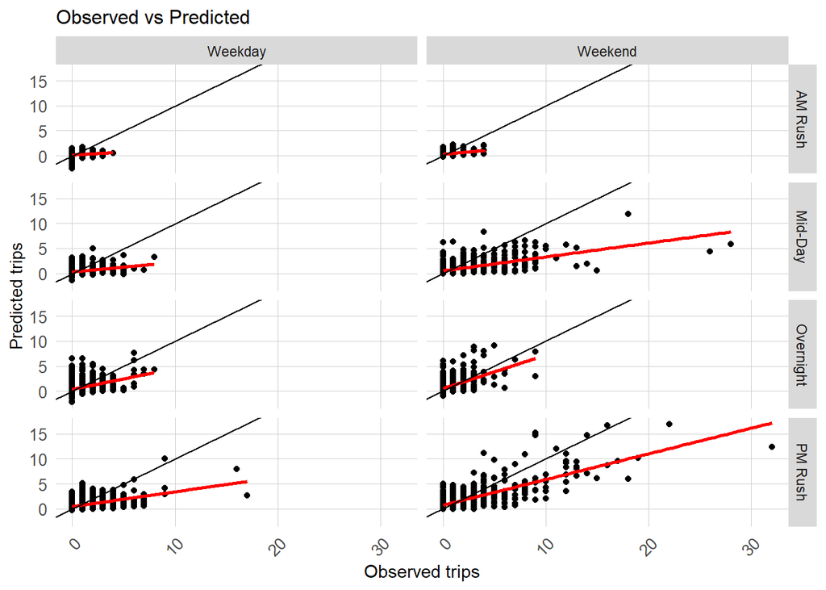

```r
week_predictions %>%
    mutate(interval60 = map(data, pull, interval60),
           start.station.id = map(data, pull, start.station.id),
           from_latitude = map(data, pull, from_latitude),
           from_longitude = map(data, pull, from_longitude),
           dotw = map(data, pull, dotw)) %>%
    select(interval60, start.station.id, from_longitude,
           from_latitude, Observed, Prediction, Regression,
           dotw) %>%
    unnest() %>%
  filter(Regression == "ETime_Space_FE_timeLags_holidayLags")%>%
  mutate(weekend = ifelse(dotw %in% c("Sun", "Sat"), "Weekend", "Weekday"),
         time_of_day = case_when(hour(interval60) < 7 | hour(interval60) > 18 ~ "Overnight",
                                 hour(interval60) >= 7 & hour(interval60) < 10 ~ "AM Rush",
                                 hour(interval60) >= 10 & hour(interval60) < 15 ~ "Mid-Day",
                                 hour(interval60) >= 15 & hour(interval60) <= 18 ~ "PM Rush"))%>%
  ggplot()+
  geom_point(aes(x= Observed, y = Prediction))+
    geom_smooth(aes(x= Observed, y= Prediction), method = "lm", se = FALSE, color = "red")+
    geom_abline(slope = 1, intercept = 0)+
  facet_grid(time_of_day~weekend)+
  labs(title="Observed vs Predicted",
       x="Observed trips",
       y="Predicted trips")+
  plotTheme
```

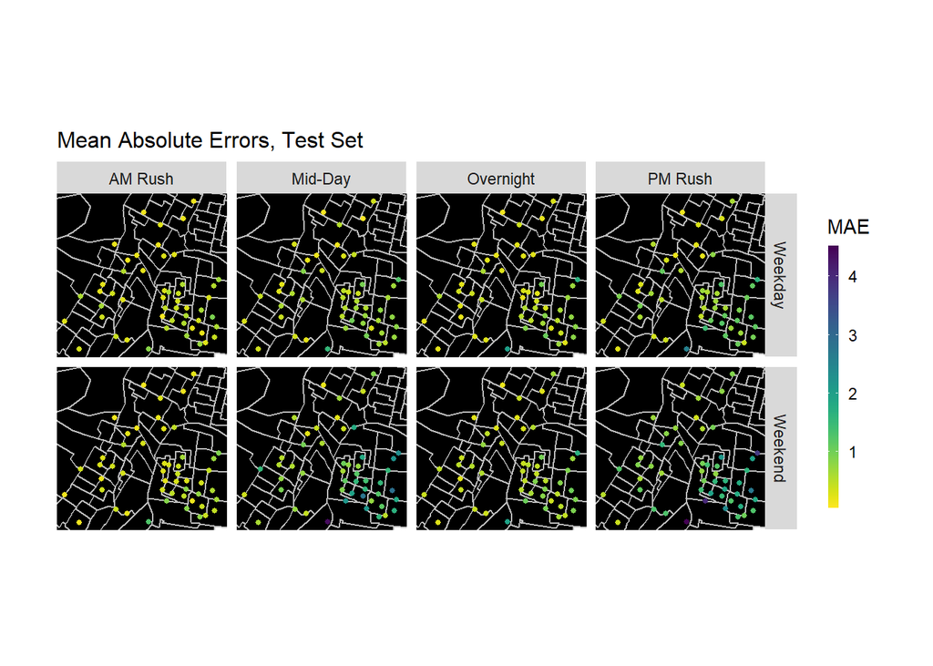

```r
week_predictions %>%
    mutate(interval60 = map(data, pull, interval60),
           start.station.id = map(data, pull, start.station.id),
           from_latitude = map(data, pull, from_latitude),
           from_longitude = map(data, pull, from_longitude),
           dotw = map(data, pull, dotw) ) %>%
    select(interval60, start.station.id, from_longitude,
           from_latitude, Observed, Prediction, Regression,
           dotw) %>%
    unnest() %>%
  filter(Regression == "ETime_Space_FE_timeLags_holidayLags")%>%
  mutate(weekend = ifelse(dotw %in% c("Sun", "Sat"), "Weekend", "Weekday"),
         time_of_day = case_when(hour(interval60) < 7 | hour(interval60) > 18 ~ "Overnight",
                                 hour(interval60) >= 7 & hour(interval60) < 10 ~ "AM Rush",
                                 hour(interval60) >= 10 & hour(interval60) < 15 ~ "Mid-Day",
                                 hour(interval60) >= 15 & hour(interval60) <= 18 ~ "PM Rush")) %>%
  group_by(start.station.id, weekend, time_of_day, from_longitude, from_latitude) %>%
  summarize(MAE = mean(abs(Observed-Prediction), na.rm = TRUE))%>%
  ggplot(.)+
  geom_sf(data = Census, color = "grey", fill = "black")+
  geom_point(aes(x = from_longitude, y = from_latitude, color = MAE),
             fill = "transparent", size = 1, alpha = 1)+
  scale_colour_viridis(direction = -1,
  discrete = FALSE, option = "D")+
  ylim(min(dat_census$from_latitude), max(dat_census$from_latitude))+
  xlim(min(dat_census$from_longitude), max(dat_census$from_longitude))+
  facet_grid(weekend~time_of_day)+
  labs(title="Mean Absolute Errors, Test Set")+
  mapTheme
```

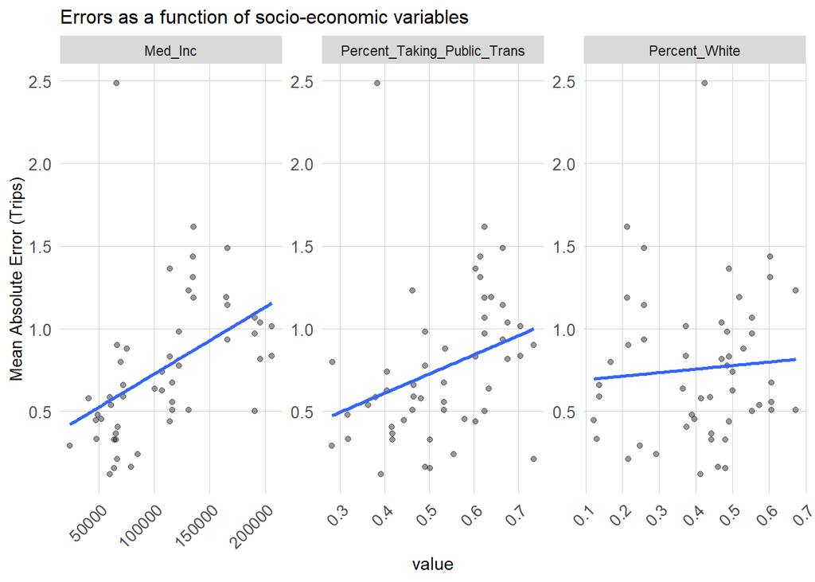

```r
week_predictions %>%
    mutate(interval60 = map(data, pull, interval60),
           start.station.id = map(data, pull, start.station.id),
           from_latitude = map(data, pull, from_latitude),
           from_longitude = map(data, pull, from_longitude),
           dotw = map(data, pull, dotw),
           Percent_Taking_Public_Trans = map(data, pull, Percent_Taking_Public_Trans),
           Med_Inc = map(data, pull, Med_Inc),
           Percent_White = map(data, pull, Percent_White)) %>%
    select(interval60, start.station.id, from_longitude,
           from_latitude, Observed, Prediction, Regression,
           dotw, Percent_Taking_Public_Trans, Med_Inc, Percent_White) %>%
    unnest() %>%
  filter(Regression == "ETime_Space_FE_timeLags_holidayLags")%>%
  mutate(weekend = ifelse(dotw %in% c("Sun", "Sat"), "Weekend", "Weekday"),
         time_of_day = case_when(hour(interval60) < 7 | hour(interval60) > 18 ~ "Overnight",
                                 hour(interval60) >= 7 & hour(interval60) < 10 ~ "AM Rush",
                                 hour(interval60) >= 10 & hour(interval60) < 15 ~ "Mid-Day",
                                 hour(interval60) >= 15 & hour(interval60) <= 18 ~ "PM Rush")) %>%
  filter(time_of_day == "Mid-Day") %>%
  group_by(start.station.id, Percent_Taking_Public_Trans, Med_Inc, Percent_White) %>%
  summarize(MAE = mean(abs(Observed-Prediction), na.rm = TRUE))%>%
  gather(-start.station.id, -MAE, key = "variable", value = "value")%>%
  ggplot(.)+
  #geom_sf(data = Census, color = "grey", fill = "transparent")+
  geom_point(aes(x = value, y = MAE), alpha = 0.4)+
  geom_smooth(aes(x = value, y = MAE), method = "lm", se= FALSE)+
  facet_wrap(~variable, scales = "free")+
  labs(title="Errors as a function of socio-economic variables",
       y="Mean Absolute Error (Trips)")+
  plotTheme
```

# 6 Conclusions

Based on the performance of the model, it is pretty useful for the bike re-balancing plan. For a particular day and a station, the model can be used to predict the demand of trips every hour with error less than 1 trip.

According to the prediction, there will be several high volume periods every day. Before those period, the bike share company can check the status of bike distribution for each station, and move bikes between stations to meet the demand of high volume periods.

Although the model underpredicts the peak, and there might be some spatial process for the error, the model is generally effective. To improve the model, adding spatial lag components or specific spatial process as predictors might be useful.